# Carlos Michel Mourra Díaz

# Captura de Datos

## Busqueda de proyectos

```r
library("recount3")
```

Encontramos todos los proyectos realizados en humanos.

```r
# Capturamos todos los proyectos en humanos
human_projects <- available_projects()
```

Vemos cuales son los proyectos que podemos elegir.

```r
# Exploramos los proyectos humanos
human_projects
```

| project | organism | file_source | project_home | project_type | n_samples |
| --- | --- | --- | --- | --- | --- |
| SRP107565 | human | sra | data_sources/sra | data_sources | 216 |
| SRP149665 | human | sra | data_sources/sra | data_sources | 4 |
| SRP017465 | human | sra | data_sources/sra | data_sources | 23 |
| SRP119165 | human | sra | data_sources/sra | data_sources | 6 |
| SRP133965 | human | sra | data_sources/sra | data_sources | 12 |
| SRP096765 | human | sra | data_sources/sra | data_sources | 7 |
| SRP124965 | human | sra | data_sources/sra | data_sources | 12 |
| SRP189165 | human | sra | data_sources/sra | data_sources | 15 |
| SRP050365 | human | sra | data_sources/sra | data_sources | 10 |
| SRP123065 | human | sra | data_sources/sra | data_sources | 41 |

[output cut: 8732 more lines]

Para este caso elegimos el proyecto SRP071965 acerca de la identificación de biomarcadores sanguíneos que predicen prospectivamente la progresión de la infección por Mycobacterium tuberculosis, esto con el proposito de poder detectar lo mas pronto posible la enfermedad.

Estos estudios fueron realizados en Sudafrica y Gambia.

Para mas información visita NCBI: [https://www.ncbi.nlm.nih.gov/sra/SRX2469204[accn]](https://www.ncbi.nlm.nih.gov/sra/SRX2469204%5Baccn%5D)

```r
# Capturamos nuestro proyecto de interes
rse_gene_SRP071965  <- create_rse(
    subset(
        human_projects,
        project == "SRP071965" & project_type == "data_sources"
    )
)
```

```r
# Exploramos la información de nuestro proyecto
rse_gene_SRP071965
```

```
## class: RangedSummarizedExperiment
## dim: 63856 355
## metadata(8): time_created recount3_version ... annotation recount3_url
## assays(1): raw_counts
## rownames(63856): ENSG00000278704.1 ENSG00000277400.1 ...
##   ENSG00000182484.15_PAR_Y ENSG00000227159.8_PAR_Y
## rowData names(10): source type ... havana_gene tag
## colnames(355): SRR3235782 SRR3235783 ... SRR3236076 SRR5151120
## colData names(175): rail_id external_id ...
##   recount_pred.curated.cell_line BigWigURL
```

Podemos ver que tenemos 63856 genes en 355 muestras

Con compute_read_counts obtendremos el numero de lecturas para cada una de las muestras en lugar de los datos a nivel de nucleotidos.

```r
# Cambiar el numero de lecturas de nucleotidos a muestras
assay(rse_gene_SRP071965 , "counts") <- compute_read_counts(rse_gene_SRP071965)
```

# Exploración de datos

Si queremos revisar la información contenida en las columnas

```r
head(colData(rse_gene_SRP071965))
```

Si queremos revisar la información contenida en rowData

```r
rowData(rse_gene_SRP071965)
```

La variable de sra.sample_attributes, nos permite ver si la información viene diferente entre las muestras.

```r
rse_gene_SRP071965$sra.sample_attributes[1:4]
```

```
## [1] "age;;14|bin;;10|ethnicity;;coloured|gender;;male|group;;control (non-progressor)|previous diagnosis of tb;;n|qft;;NA|source_name;;Blood, control|tissue;;blood|tst;;NA"
## [2] "age;;12|bin;;2|ethnicity;;coloured|gender;;female|group;;case (TB progressor)|previous diagnosis of tb;;n|qft;;positive|source_name;;Blood, case|tissue;;blood|tst;;18.1"
## [3] "age;;12|bin;;2|ethnicity;;coloured|gender;;female|group;;case (TB progressor)|previous diagnosis of tb;;n|qft;;NA|source_name;;Blood, case|tissue;;blood|tst;;NA"
## [4] "age;;16|bin;;21|ethnicity;;coloured|gender;;male|group;;case (TB progressor)|previous diagnosis of tb;;n|qft;;positive|source_name;;Blood, case|tissue;;blood|tst;;15.5"
```

```r
library("edgeR")
```

Podemos observar que las lineas poseen la misma cantidad de campos, por lo que podemos proceder a observar la información contenida en las columnas por medio de expand_sra_attributes.

```r
rse_gene_SRP071965 <- expand_sra_attributes(rse_gene_SRP071965)
colData(rse_gene_SRP071965)[
    ,
    grepl("^sra_attribute", colnames(colData(rse_gene_SRP071965)))
]
```

```
## DataFrame with 355 rows and 10 columns
##            sra_attribute.age sra_attribute.bin sra_attribute.ethnicity
##                  <character>       <character>             <character>
## SRR3235782                14                10                coloured
## SRR3235783                12                 2                coloured
## SRR3235784                12                 2                coloured
## SRR3235785                16                21                coloured
## SRR3235786                16                21                coloured
## ...                      ...               ...                     ...
## SRR3235995                13                 3                coloured
## SRR3235996                13                 4                coloured
## SRR3235997                13                 4                coloured
## SRR3236076                17                23                coloured
## SRR5151120                17                24                coloured
##            sra_attribute.gender    sra_attribute.group
##                     <character>            <character>
## SRR3235782                 male control (non-progres..
## SRR3235783               female   case (TB progressor)
## SRR3235784               female   case (TB progressor)
## SRR3235785                 male   case (TB progressor)
## SRR3235786                 male   case (TB progressor)
## ...                         ...                    ...
## SRR3235995               female control (non-progres..
## SRR3235996               female control (non-progres..
## SRR3235997               female control (non-progres..
## SRR3236076               female control (non-progres..
## SRR5151120                 male control (non-progres..
##            sra_attribute.previous_diagnosis_of_tb sra_attribute.qft
##                                       <character>       <character>
## SRR3235782                                      n                NA
## SRR3235783                                      n          positive
## SRR3235784                                      n                NA
## SRR3235785                                      n          positive
## SRR3235786                                      n                NA
## ...                                           ...               ...
## SRR3235995                                      n                NA
## SRR3235996                                      y                NA
## SRR3235997                                      y                NA
## SRR3236076                                      y                NA
## SRR5151120                                      n                NA
##            sra_attribute.source_name sra_attribute.tissue sra_attribute.tst
##                          <character>          <character>       <character>
## SRR3235782            Blood, control                blood                NA
## SRR3235783               Blood, case                blood              18.1
## SRR3235784               Blood, case                blood                NA
## SRR3235785               Blood, case                blood              15.5
## SRR3235786               Blood, case                blood                NA
## ...                              ...                  ...               ...
## SRR3235995            Blood, control                blood                NA
## SRR3235996            Blood, control                blood                NA
## SRR3235997            Blood, control                blood                NA
## SRR3236076            Blood, control                blood                NA
## SRR5151120            Blood, control                blood                NA
```

Observamos los valores unicos de cada uno de los campos que tiene el experimento, para saber las condiciones a evaluar.

```r
# Accedemos a los valores unicos de los datos
print("Group")
```

```
## [1] "Group"
```

```r
unique(rse_gene_SRP071965$sra_attribute.group)
```

```
## [1] "control (non-progressor)" "case (TB progressor)"
```

```r
print("Gender")
```

```
## [1] "Gender"
```

```r
unique(rse_gene_SRP071965$sra_attribute.gender)
```

```
## [1] "male"   "female"
```

```r
print("Ethnicity")
```

```
## [1] "Ethnicity"
```

```r
unique(rse_gene_SRP071965$sra_attribute.ethnicity)
```

```
## [1] "coloured" "black"
```

Debemos fijarnos que hay variables numéricas y factores por lo que debemos hacer una corrección de estos datos.

```r
## Podemos pasar los atributos de edad y bin a variable tipo numerica
rse_gene_SRP071965$sra_attribute.age <- as.numeric(rse_gene_SRP071965$sra_attribute.age)

rse_gene_SRP071965$sra_attribute.bin <- as.numeric(rse_gene_SRP071965$sra_attribute.bin)

## Podemos pasar el grupo etnico, el grupo y el genero a factor
rse_gene_SRP071965$sra_attribute.group <- factor(rse_gene_SRP071965$sra_attribute.group)

rse_gene_SRP071965$sra_attribute.ethnicity <- factor(rse_gene_SRP071965$sra_attribute.ethnicity)

rse_gene_SRP071965$sra_attribute.gender <- factor(rse_gene_SRP071965$sra_attribute.gender)
```

Observamos la información de cada uno de los campos para proceder con la limpieza de los datos

```r
## Resumen de las variables de interés y mostramos la información relevante de cada campo
summary(as.data.frame(colData(rse_gene_SRP071965)[
    ,
    grepl("^sra_attribute.[group|age|bin|ethnicity|gender]", colnames(colData(rse_gene_SRP071965)))
]))
```

```
##  sra_attribute.age sra_attribute.bin sra_attribute.ethnicity
##  Min.   :12.00     Min.   : 1.00     black   : 22
##  1st Qu.:15.00     1st Qu.:11.00     coloured:333
##  Median :16.00     Median :17.00
##  Mean   :15.69     Mean   :16.68
##  3rd Qu.:17.00     3rd Qu.:23.00
##  Max.   :18.00     Max.   :32.00
##  sra_attribute.gender               sra_attribute.group
##  female:250           case (TB progressor)    :110
##  male  :105           control (non-progressor):245
##
##
##
##
##  sra_attribute.previous_diagnosis_of_tb sra_attribute.tissue sra_attribute.tst
##  Length:355                             Length:355           Length:355
##  Class :character                       Class :character     Class :character
##  Mode  :character                       Mode  :character     Mode  :character
##
##
##
```

# Análisis de datos

Se inspecciona el estado de las muestras de los pacientes, cuantos corresponden a un paciente control y cuantos tienen el padecimiento.

```r
#generamos nuestra columna dependiendo de si el paciente es control o caso
rse_gene_SRP071965$Group <- factor(ifelse(rse_gene_SRP071965$sra_attribute.group == "control (non-progressor)", "Control", "Case"))

table(rse_gene_SRP071965$Group)
```

```
##
##    Case Control
##     110     245
```

Basado en las variables de control de calidad se dividira el numero de lecturas asignadas a los genes dividido entre el numero de lecturas totales, esto nos dara la proporción de lecturas asignadas a los genes.

Esto nos indicara cuales son las muestras malas

```r
# Desplegamos la expresión
rse_gene_SRP071965$assigned_gene_prop <- rse_gene_SRP071965$recount_qc.gene_fc_count_all.assigned / rse_gene_SRP071965$recount_qc.gene_fc_count_all.total
summary(rse_gene_SRP071965$assigned_gene_prop)
```

```
##    Min. 1st Qu.  Median    Mean 3rd Qu.    Max.
##  0.3855  0.6417  0.6806  0.6707  0.7087  0.7792
```

Se da un vistazo general de la expresión de los genes en las muestras, colocando el punto de corte en donde se localiza el primer cuartil.

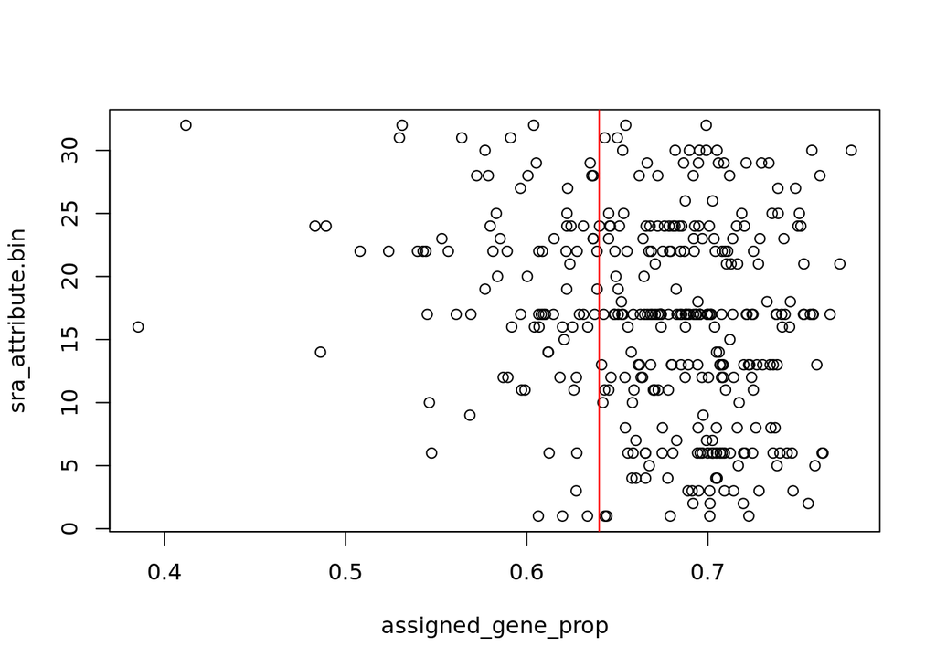

```r
# Realizamos un plot de la expresión
with(colData(rse_gene_SRP071965), plot(assigned_gene_prop, sra_attribute.bin))
abline(v=0.64,col = "red")
```

Con tapply se observara como varian las muestras, dependiendo la condición del paciente donde fue tomada.

Se observa que no hay muchas diferencias entre ambas condiciones

```r
with(colData(rse_gene_SRP071965), tapply(assigned_gene_prop, Group, summary))
```

```
## $Case
##    Min. 1st Qu.  Median    Mean 3rd Qu.    Max.
##  0.5297  0.6566  0.6921  0.6817  0.7200  0.7792
##
## $Control
##    Min. 1st Qu.  Median    Mean 3rd Qu.    Max.
##  0.3855  0.6367  0.6749  0.6658  0.7068  0.7636
```

# Limpieza de muestras

Gracias a la información observada con anterioridad se procedera con la limpieza de las muestras poco informativas. Para esto utilizaremos como punto de corte el primer Cuartil.

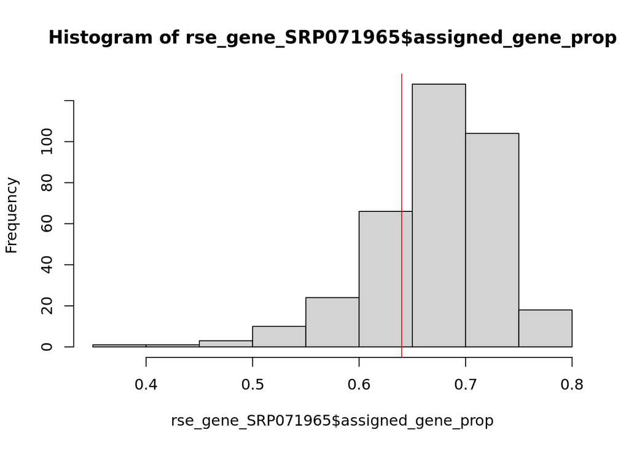

```r
## Guardemos nuestro objeto entero por si luego cambiamos de opinión
rse_gene_SRP071965_unfiltered <- rse_gene_SRP071965

## Eliminemos a muestras malas
hist(rse_gene_SRP071965$assigned_gene_prop)
abline(v=0.64,col="red")
```

Observamos cuantos cumplen con el punto de corte establecido tras la observación, por lo que esto nos indicaria la cantidad de muestras que seran eliminadas.

```r
table(rse_gene_SRP071965$assigned_gene_prop < 0.64)
```

```
##
## FALSE  TRUE
##   268    87
```

Se calcula los nuevos valores una vez hecho el filtrado de las muestras que no son genes, de esta manera podremos encontrar cuales son lo genes poco informativos y filtrarlos.

```r
rse_gene_SRP071965 <- rse_gene_SRP071965[, rse_gene_SRP071965$assigned_gene_prop > 0.64]

## Calculemos los niveles medios de expresión de los genes en nuestras
## muestras.
## Ojo: en un análisis real probablemente haríamos esto con los RPKMs o CPMs
## en vez de las cuentas.
gene_means <- rowMeans(assay(rse_gene_SRP071965, "counts"))
summary(gene_means)
```

```
##      Min.   1st Qu.    Median      Mean   3rd Qu.      Max.
##      0.00      0.01      0.48    449.64     47.42 242366.31
```

# Limpieza de genes

Se realiza la limpieza de los genes poco informativos utilizando el primer cuartil de 0.01 observado.

```r
## Eliminamos genes
rse_gene_SRP071965 <- rse_gene_SRP071965[gene_means > 0.01, ]

## Dimensiones finales
dim(rse_gene_SRP071965)
```

```
## [1] 47601   268
```

Cantidad de genes antes de hacer el filtrado

```r
## Dimensiones finales
dim(rse_gene_SRP071965_unfiltered)
```

```
## [1] 63856   355
```

Vemos que debido a la calidad se tuvo que limpiar al rededor de un 25% de las muestras.

```r
round(nrow(rse_gene_SRP071965) / nrow(rse_gene_SRP071965_unfiltered) * 100, 2)
```

```
## [1] 74.54
```

# Normalización de los datos

Como existe el problema de que en ambas muestras pueden existir diferente cantidad de genes expresados, podria ocurrir que genes se expresan de la misma manera pero aun asi se detectaria como expresión diferencial.

Para ello deben normalizarse los datos asumiendo que la mayoria de los genes no se estan expresando diferencialmente.

```r
# Utilizamos una libreria para normalizar los datos
library("edgeR") # BiocManager::install("edgeR", update = FALSE)
dge <- DGEList(
    counts = assay(rse_gene_SRP071965, "counts"),
    genes = rowData(rse_gene_SRP071965)
)

# Calcular los factores de normalización de acuerdo al artículo del 2010
dge <- calcNormFactors(dge)
```

# Analisis de expresión diferencial con Gráficos

En este caso se realizo un análisis por medio de boxplot, en el cual se pudo ver la diferencia entre la expresión de las muestras en pacientes control y los que poseen.

Existe poca diferencia entre los genes de paciente control y pacientes con el padecimiento de los biomarcadores en sangre.

También se realizaron otros análisis de acuerdo a su genero y su grupo étnico

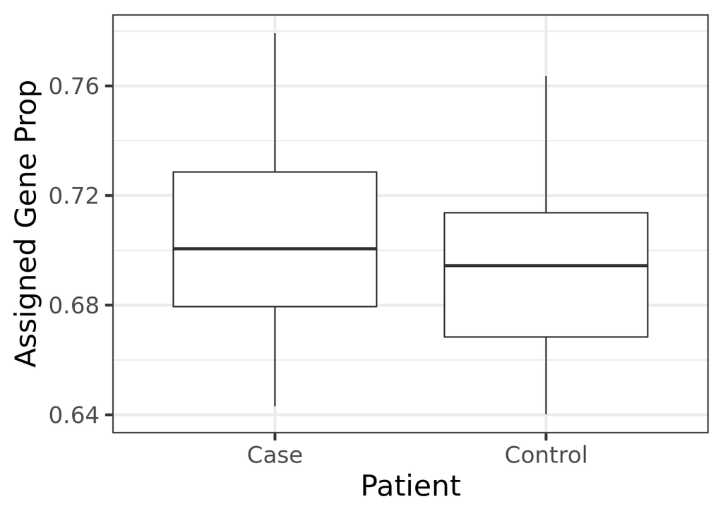

```r
library("ggplot2")
ggplot(as.data.frame(colData(rse_gene_SRP071965)), aes(y = assigned_gene_prop, x = Group)) +
    geom_boxplot() +
    theme_bw(base_size = 20) +
    ylab("Assigned Gene Prop") +
    xlab("Patient")
```

Igualmente se hace un boxplot para género

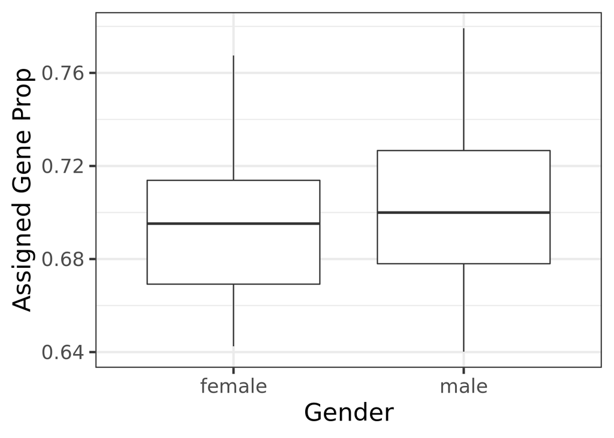

```r
ggplot(as.data.frame(colData(rse_gene_SRP071965)), aes(y = assigned_gene_prop, x = sra_attribute.gender)) +
    geom_boxplot() +
    theme_bw(base_size = 20) +
    ylab("Assigned Gene Prop") +
    xlab("Gender")
```

Se hace un boxplot para grupo étnico

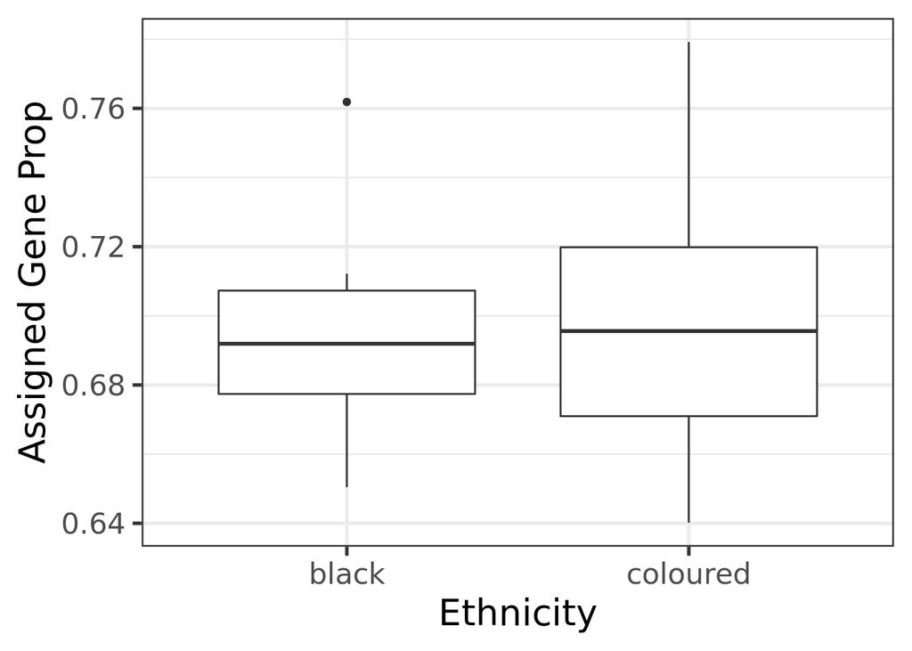

```r
ggplot(as.data.frame(colData(rse_gene_SRP071965)), aes(y = assigned_gene_prop, x = sra_attribute.ethnicity)) +
    geom_boxplot() +
    theme_bw(base_size = 20) +
    ylab("Assigned Gene Prop") +
    xlab("Ethnicity")
```

Se genera el modelo estadistico de acuerdo con las variables de nuestro interes.

```r
# Generar el modelo linear estadistico
mod <- model.matrix(~ Group + sra_attribute.age + sra_attribute.gender + sra_attribute.ethnicity + sra_attribute.bin + assigned_gene_prop,
    data = colData(rse_gene_SRP071965)
)
# Observar las variables que componen nuestro modelo
colnames(mod)
```

```
## [1] "(Intercept)"                     "GroupControl"
## [3] "sra_attribute.age"               "sra_attribute.gendermale"
## [5] "sra_attribute.ethnicitycoloured" "sra_attribute.bin"
## [7] "assigned_gene_prop"
```

Una vez que se tienen las cuentas, se utiliza el paquete limma el cual integra modelos de regresión lineal.

De esta manera se puede obtener mejores estimados de la desviación estandar.

Los genes que estan abajo de la curva son los de baja expresión.

La gráfica refleja la desviación estandar para cada gen en el eje y, y un valor de expresión de cada gen en escala de log2 en el eje x.

Se debe acercar los genes que estan lejos de la curva roja, por lo que se podra hacer un ajuste.

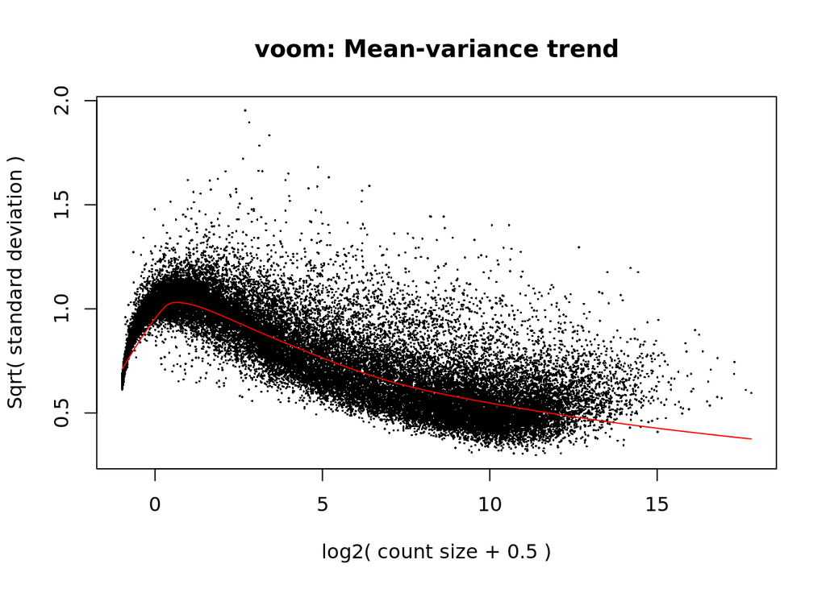

```r
# Generamos el plot
library("limma")
vGene <- voom(dge, mod, plot = TRUE)
```

Se generará el modelo de regresión lineal y se explorara los resultados de los genes.

```r
# modelo de regresión lineal con lmfit
eb_results <- eBayes(lmFit(vGene))

# indicamos el coeficiente de ual es el modelo que nos interesa
de_results <- topTable(
    eb_results,
    coef = 2,
    number = nrow(rse_gene_SRP071965),
    sort.by = "none"
)
dim(de_results)
```

```
## [1] 47601    16
```

Se observan los resultados estadísticos generados por el modelo lineal.

```r
head(de_results)
```

|  | source | type | score | phase | gene_id | gene_type | gene_name | level | havana_gene | tag | logFC | AveExpr | t | P.Value | adj.P.Val | B |
| --- | --- | --- | --- | --- | --- | --- | --- | --- | --- | --- | --- | --- | --- | --- | --- | --- |
| ENSG00000223972.5 | HAVANA | gene | 1735 | NA | ENSG00000223972.5 | transcribed_unprocessed_pseudogene | DDX11L1 | 2 | OTTHUMG00000000961.2 | NA | 0.047333837 | -0.1471210 | 0.3184365 | 0.75040296 | 0.83621901 | -6.059558 |
| ENSG00000278267.1 | ENSEMBL | gene | 68 | NA | ENSG00000278267.1 | miRNA | MIR6859-1 | 3 | NA | NA | 0.065133274 | -0.8707374 | 1.1113263 | 0.26742824 | 0.40762918 | -5.412725 |
| ENSG00000227232.5 | HAVANA | gene | 1351 | NA | ENSG00000227232.5 | unprocessed_pseudogene | WASH7P | 2 | OTTHUMG00000000958.1 | NA | 0.004874366 | 4.4749138 | 0.1229915 | 0.90220638 | 0.93862670 | -6.727998 |
| ENSG00000284332.1 | ENSEMBL | gene | 138 | NA | ENSG00000284332.1 | miRNA | MIR1302-2 | 3 | NA | NA | -0.185009332 | -5.6079978 | -2.3864628 | 0.01770861 | 0.04876434 | -3.473185 |
| ENSG00000243485.5 | HAVANA | gene | 1021 | NA | ENSG00000243485.5 | lincRNA | MIR1302-2HG | 2 | OTTHUMG00000000959.2 | ncRNA_host | -0.059370953 | -4.5285281 | -0.4517527 | 0.65181409 | 0.76210951 | -5.650470 |
| ENSG00000237613.2 | HAVANA | gene | 1219 | NA | ENSG00000237613.2 | lincRNA | FAM138A | 2 | OTTHUMG00000000960.1 | NA | -0.066149357 | -5.1990074 | -0.5083836 | 0.61160436 | 0.73028920 | -5.892273 |

Se inspecciona la cantidad de genes diferencialmente expresados con un p-value adecuado.

```r
## Genes diferencialmente expresados entre embrion y humano con FDR < 5%
table(de_results$adj.P.Val < 0.05)
```

```
##
## FALSE  TRUE
## 30205 17396
```

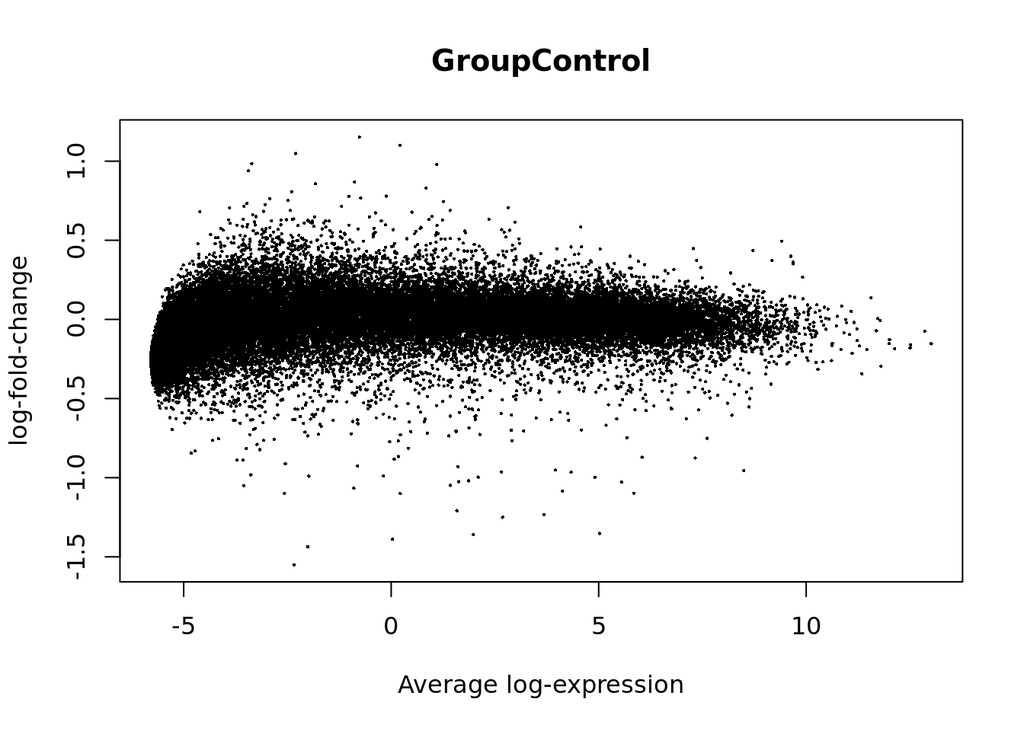

```r
## Visualicemos los resultados estadísticos
plotMA(eb_results, coef = 2)
```

Por medio de un volcano plot podemos ver el logfold change en el eje x y el valor p en el eje y. De este modo se pueden observar los genes con mayor expresión y con mejor valor de p-value.

Se resaltan los 3 genes

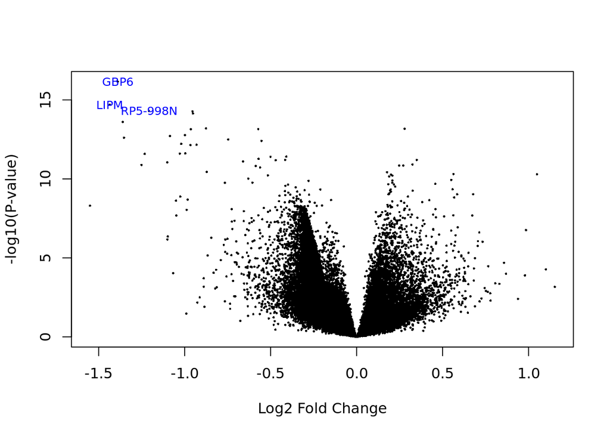

```r
# Generar el plot con 3 genes resaltados
volcanoplot(eb_results, coef = 2, highlight = 3, names = de_results$gene_name)
```

```r
de_results[de_results$gene_name %in% c("GBP6", "LIPM", "RP5-998N21.4"), ]
```

|  | source | type | score | phase | gene_id | gene_type | gene_name | level | havana_gene | tag | logFC | AveExpr | t | P.Value | adj.P.Val | B |
| --- | --- | --- | --- | --- | --- | --- | --- | --- | --- | --- | --- | --- | --- | --- | --- | --- |
| ENSG00000183347.14 | HAVANA | gene | 2987 | NA | ENSG00000183347.14 | protein_coding | GBP6 | 2 | OTTHUMG00000010123.1 | NA | -1.388887 | 0.03120104 | -8.931382 | 7.031235e-17 | 3.346938e-12 | 27.22267 |
| ENSG00000234571.1 | HAVANA | gene | 3540 | NA | ENSG00000234571.1 | lincRNA | RP5-998N21.4 | 2 | OTTHUMG00000041032.2 | overlapping_locus | -1.208002 | 1.58232311 | -8.308763 | 4.938583e-15 | 6.320970e-11 | 23.50239 |
| ENSG00000173239.13 | HAVANA | gene | 1511 | NA | ENSG00000173239.13 | protein_coding | LIPM | 2 | OTTHUMG00000018698.4 | NA | -1.436025 | -2.00901779 | -8.439636 | 2.048793e-15 | 4.876229e-11 | 23.16022 |

Observamos la expresión de los genes dependiendo todas las condiciones que análizamos en nuestro modelo.

Extraemos la información de los primeros 50 genes junto con sus valores de expresión.

De igual manera es posible observar los modulos que se forman entre los genes debido a las condiciones y a los metodos de clustering.

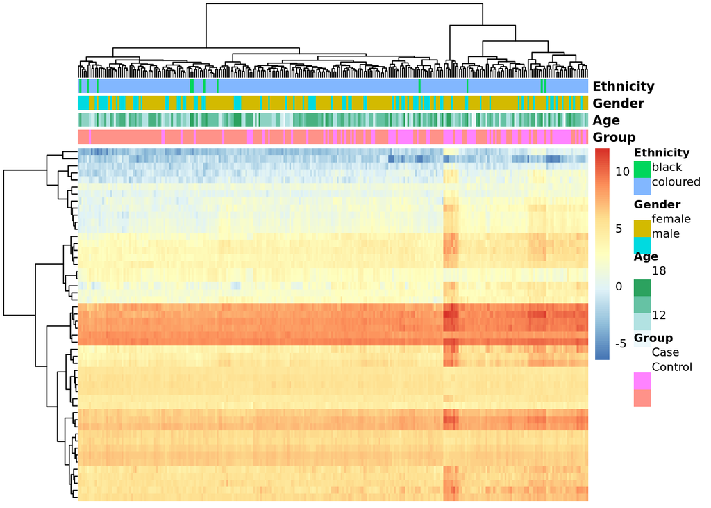

```r
## Extraer valores de los genes de interés
exprs_heatmap <- vGene$E[rank(de_results$adj.P.Val) <= 50, ]

## Creemos una tabla con información de las muestras
## y con nombres de columnas más amigables
df <- as.data.frame(colData(rse_gene_SRP071965)[, c("Group", "sra_attribute.age", "sra_attribute.gender","sra_attribute.ethnicity")])
colnames(df) <- c("Group", "Age", "Gender", "Ethnicity")

## Hagamos un heatmap
library("pheatmap")
pheatmap(
    exprs_heatmap,
    cluster_rows = TRUE,
    cluster_cols = TRUE,
    show_rownames = FALSE,
    show_colnames = FALSE,
    cex = 0.9,
    annotation_col = df
)
```

```r
## Para colores
library("RColorBrewer")

## Conviertiendo los grupos de edad a colores
col.group <- df$Group
levels(col.group) <- brewer.pal(nlevels(col.group), "Set1")
```

Por medio de la funcion plotMDS se gráficara la expresión de los genes dependiendo del grupo al que pertenezcan.